# 04. Tipos y funcionamiento de las pulverizadoras

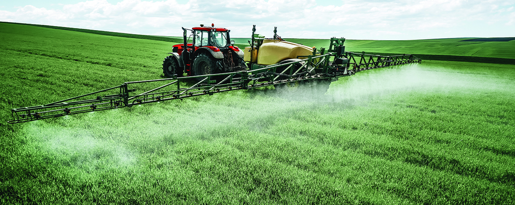

Fuente: www.tvh.com

### 1. Introducción

Las máquinas pulverizadoras son una herramienta fundamental en la agricultura moderna. Permiten aplicar productos fitosanitarios (como herbicidas, fungicidas e insecticidas) de manera controlada sobre los cultivos, para protegerlos de plagas, enfermedades y malezas. Existen distintos tipos de pulverizadoras, y cada una tiene características estructurales y operativas particulares.

### 2. Tipos de pulverizadoras

#### Pulverizadoras de arrastre

Estas [pulverizadoras](https://upload.wikimedia.org/wikipedia/commons/7/7d/Opryskiwacz_Pilmet_Europa_2500.jpg) son aquellas que se enganchan a un tractor. El tractor se encarga de mover la pulverizadora y, en algunos casos, también de accionar la bomba hidráulica o de presión. Son muy utilizadas en explotaciones medianas y pequeñas.

**Ventajas**: - Menor costo inicial que una autopropulsada. - Versatilidad en distintos terrenos.

**Desventajas**: - Menor maniobrabilidad. - Mayor tiempo de preparación y enganche.

#### Pulverizadoras autopropulsadas

Estas [pulverizadoras](https://upload.wikimedia.org/wikipedia/commons/thumb/8/84/1264_Rogator_Spraying_Corn.JPG/800px-1264_Rogator_Spraying_Corn.JPG) son vehículos diseñados exclusivamente para pulverizar, con motor propio, cabina y sistemas hidráulicos y electrónicos integrados. Se utilizan especialmente en explotaciones grandes o con alta demanda de trabajo.

**Ventajas**: - Mayor eficiencia y autonomía. - Tecnología avanzada (piloto automático, sensores, control por GPS). - Mejor distribución del peso y menor compactación del suelo.

**Desventajas**: - Costo elevado. - Mantenimiento más complejo.

### 3. Estructura funcional de una pulverizadora

Una pulverizadora típica, sea de arrastre o autopropulsada, está formada por esttas partes principales que se describen en este [video](https://www.youtube.com/watch?v=nHF_EBICnmc) entre el minuto `0:40` y el `3:22`.

**Con bomba volumétrica**

Son muy comunes y en la figura de abajo se muestran las partes.

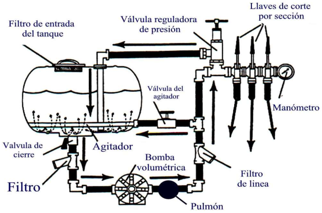

Fuente: Ingeniería Rural 2.0. Esquema de una pulverizadora con bomba volumétrica

**[Con bomba centrífuga](https://encrypted-tbn0.gstatic.com/images?q=tbn:ANd9GcSfVwPLnU-4Mq3mavJ23kakfaWq3HjgO_6JSQ&s)**

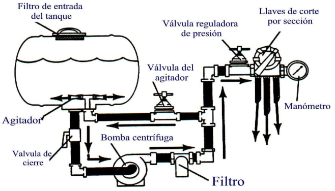

Fuente: Ingeniería Rural 2.0. Esquema de una pulverizadora con bomba centrífuga

### 4. Actividades

(Estas actividades o tareas deben estar en la carpeta)

1. Mira este [video](https://www.youtube.com/watch?v=M-ReHoyvBwA) que compara las bombas centrífugas y las volumétricas y escribe al menos tres diferencias entre las mismas.
2. **Investigación local**: averiguá qué modelos de pulverizadoras usan los productores en tu zona. ¿Qué marca es la más común? ¿Usan más arrastre o autopropulsadas?